# SEM Strategies for COIL-related Data

Juan C. Correa

2024-02-01

In this Supplementary Material, we will show two strategies of structural equation modeling. In our first strategy, we follow a “top-down modeling” which deviates from the second strategy called “bottom-up modeling” in several ways.

# Testing Univariate and Multivariate Normal Distribution Assumptions

The evaluation of these assumptions is relatively straightforward through exploratory data visualization of kernel density plots and the Henze-Zirkler test implemented in the R package MVN

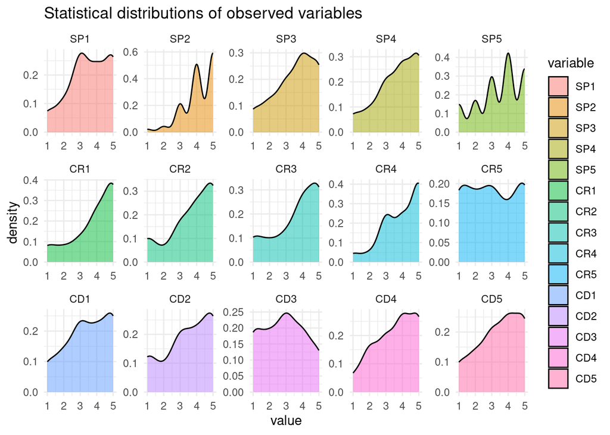

```
## $multivariate_normality
##            Test Statistic p.value     Method          MVN
## 1 Henze-Zirkler     1.147  <0.001 asymptotic ✗ Not normal
##
## $univariate_normality
##                Test Variable Statistic p.value    Normality
## 1  Anderson-Darling      SP1     2.643  <0.001 ✗ Not normal
## 2  Anderson-Darling      SP2     4.807  <0.001 ✗ Not normal
## 3  Anderson-Darling      SP3     2.805  <0.001 ✗ Not normal
## 4  Anderson-Darling      SP4     3.199  <0.001 ✗ Not normal
## 5  Anderson-Darling      SP5     2.606  <0.001 ✗ Not normal
## 6  Anderson-Darling      CR1     5.123  <0.001 ✗ Not normal
## 7  Anderson-Darling      CR2     4.189  <0.001 ✗ Not normal
## 8  Anderson-Darling      CR3     4.258  <0.001 ✗ Not normal
## 9  Anderson-Darling      CR4     4.332  <0.001 ✗ Not normal
## 10 Anderson-Darling      CR5     2.825  <0.001 ✗ Not normal
## 11 Anderson-Darling      CD1     2.558  <0.001 ✗ Not normal
## 12 Anderson-Darling      CD2     3.170  <0.001 ✗ Not normal
## 13 Anderson-Darling      CD3     2.087  <0.001 ✗ Not normal
## 14 Anderson-Darling      CD4     2.768  <0.001 ✗ Not normal
## 15 Anderson-Darling      CD5     2.577  <0.001 ✗ Not normal
##
## $descriptives
##    Variable  n  Mean Std.Dev Median Min Max 25th 75th   Skew Kurtosis
## 1       SP1 65 3.554   1.238      4   1   5    3    5 -0.448    2.291
## 2       SP2 65 4.169   0.911      4   1   5    4    5 -1.088    4.079
## 3       SP3 65 3.554   1.275      4   1   5    3    5 -0.577    2.297
## 4       SP4 65 3.708   1.247      4   1   5    3    5 -0.701    2.529
## 5       SP5 65 3.462   1.288      4   1   5    3    4 -0.511    2.223
## 6       CR1 65 3.892   1.312      4   1   5    3    5 -1.012    2.849
## 7       CR2 65 3.738   1.350      4   1   5    3    5 -0.861    2.604
## 8       CR3 65 3.692   1.380      4   1   5    3    5 -0.801    2.372
## 9       CR4 65 3.954   1.138      4   1   5    3    5 -0.871    3.019
## 10      CR5 65 3.015   1.515      3   1   5    2    5  0.028    1.596
## 11      CD1 65 3.446   1.335      4   1   5    3    5 -0.380    2.012
## 12      CD2 65 3.477   1.415      4   1   5    3    5 -0.519    2.036
## 13      CD3 65 2.862   1.345      3   1   5    2    4  0.060    1.867
## 14      CD4 65 3.569   1.250      4   1   5    3    5 -0.449    2.099
## 15      CD5 65 3.462   1.324      4   1   5    3    5 -0.446    2.072
##
```

[output cut: 10 more lines]

[output not shown]

These results show that the univariate and multivariate normal distribution assumptions are unmet. As a result, these violations can be a possible lead to biased estimates and a poor fit when testing the psychometric structure of the transactive memory systems scale.

# Testing Unidimensional Structures

Now, we follow a bottom-up model specification according to which we are going to test the unidimensionality of the observed variables for the specialization sub-scale, the credibility sub-scale, and the coordination sub-scale.

## Unidimensionality of Specialization

```
##                                      SP.fit
## npar                            15.00000000
## fmin                             0.02070262
## chisq                            2.69134101
## df                               5.00000000
## pvalue                           0.74744247
## chisq.scaled                     2.35808976
## df.scaled                        5.00000000
## pvalue.scaled                    0.79769859
## chisq.scaling.factor             1.14132255
## baseline.chisq                 153.97290979
## baseline.df                     10.00000000
## baseline.pvalue                  0.00000000
## baseline.chisq.scaled          108.27437551
## baseline.df.scaled              10.00000000
## baseline.pvalue.scaled           0.00000000
## baseline.chisq.scaling.factor    1.42206232
## cfi                              1.00000000
## tli                              1.03207074
## cfi.scaled                       1.00000000
## tli.scaled                       1.05376600
## cfi.robust                       1.00000000
## tli.robust                       1.04315166
## logl                          -382.99480859
## unrestricted.logl             -381.64913808
## aic                            795.98961718
## bic                            828.60542623
## ntotal                          65.00000000
## bic2                           781.38919901
## rmsea                            0.00000000
## rmsea.ci.lower                   0.00000000
## rmsea.ci.upper                   0.12145197
## rmsea.ci.level                   0.90000000
## rmsea.pvalue                     0.80654697
## rmsea.close.h0                   0.05000000
## rmsea.notclose.pvalue            0.12673918
## rmsea.notclose.h0                0.08000000
## rmsea.scaled                     0.00000000
## rmsea.ci.lower.scaled            0.00000000
## rmsea.ci.upper.scaled            0.09948800
## rmsea.pvalue.scaled              0.86972101
## rmsea.notclose.pvalue.scaled     0.07891867
## rmsea.robust                     0.00000000
## rmsea.ci.lower.robust            0.00000000
## rmsea.ci.upper.robust            0.11782540
## rmsea.pvalue.robust              0.84196979
## rmsea.notclose.pvalue.robust     0.10702837
## srmr                             0.01957034
```

| lhs | op | rhs | label | exo | est | se | z | pvalue |
| --- | --- | --- | --- | --- | --- | --- | --- | --- |
| SP | =~ | SP1 | SP__SP1 | 0 | 0.8551255 | 0.0855144 | 9.9997819 | 0.0000000 |
| SP | =~ | SP2 | SP__SP2 | 0 | 0.0790281 | 0.1704259 | 0.4637095 | 0.6428559 |
| SP | =~ | SP3 | SP__SP3 | 0 | 0.7229196 | 0.1015288 | 7.1203421 | 0.0000000 |
| SP | =~ | SP4 | SP__SP4 | 0 | 0.9227822 | 0.0900206 | 10.2507911 | 0.0000000 |
| SP | =~ | SP5 | SP__SP5 | 0 | 0.7147160 | 0.1121704 | 6.3716973 | 0.0000000 |

As expected, all factor loadings are positive and highly significant except that of the second item (SP2) whose factor loading is almost zero and non-significant ($\lambda$ = 0.079, se = 0.17, p = 0.64). This particular result will lead us to reduce the complexity of this unidimensional model for Specialization by removing SP2 from the proposed structure (i.e., just four items). If this simpler model behaves as expected we can keep it for further analyses.

```
##                                     SP2.fit
## npar                            12.00000000
## fmin                             0.01801554
## chisq                            2.34202027
## df                               2.00000000
## pvalue                           0.31005359
## chisq.scaled                     1.43775271
## df.scaled                        2.00000000
## pvalue.scaled                    0.48729950
## chisq.scaling.factor             1.62894513
## baseline.chisq                 153.24399760
## baseline.df                      6.00000000
## baseline.pvalue                  0.00000000
## baseline.chisq.scaled          113.39382693
## baseline.df.scaled               6.00000000
## baseline.pvalue.scaled           0.00000000
## baseline.chisq.scaling.factor    1.35143157
## cfi                              0.99767719
## tli                              0.99303156
## cfi.scaled                       1.00000000
## tli.scaled                       1.01570613
## cfi.robust                       1.00000000
## tli.robust                       1.01893136
## logl                          -291.45748572
## unrestricted.logl             -290.28647558
## aic                            606.91497144
## bic                            633.00761868
## ntotal                          65.00000000
## bic2                           595.23463691
## rmsea                            0.05129255
## rmsea.ci.lower                   0.00000000
## rmsea.ci.upper                   0.25720715
## rmsea.ci.level                   0.90000000
## rmsea.pvalue                     0.36708276
## rmsea.close.h0                   0.05000000
## rmsea.notclose.pvalue            0.55162345
## rmsea.notclose.h0                0.08000000
## rmsea.scaled                     0.00000000
## rmsea.ci.lower.scaled            0.00000000
## rmsea.ci.upper.scaled            0.17763594
## rmsea.pvalue.scaled              0.61897521
## rmsea.notclose.pvalue.scaled     0.29409360
## rmsea.robust                     0.00000000
## rmsea.ci.lower.robust            0.00000000
## rmsea.ci.upper.robust            0.28466261
## rmsea.pvalue.robust              0.52114998
## rmsea.notclose.pvalue.robust     0.43020921
## srmr                             0.02057845
```

| lhs | op | rhs | label | exo | est | se | z | pvalue |
| --- | --- | --- | --- | --- | --- | --- | --- | --- |
| SP | =~ | SP1 | SP__SP1 | 0 | 0.8543817 | 0.0856837 | 9.971339 | 0 |
| SP | =~ | SP3 | SP__SP3 | 0 | 0.7222787 | 0.1017186 | 7.100752 | 0 |
| SP | =~ | SP4 | SP__SP4 | 0 | 0.9237103 | 0.0901998 | 10.240715 | 0 |
| SP | =~ | SP5 | SP__SP5 | 0 | 0.7146653 | 0.1123047 | 6.363627 | 0 |

## Unidimensionality of Credibility

```
##                                      CR.fit
## npar                           1.500000e+01
## fmin                           1.389881e-01
## chisq                          1.806845e+01
## df                             5.000000e+00
## pvalue                         2.861831e-03
## chisq.scaled                   1.791212e+01
## df.scaled                      5.000000e+00
## pvalue.scaled                  3.058586e-03
## chisq.scaling.factor           1.008728e+00
## baseline.chisq                 1.708086e+02
## baseline.df                    1.000000e+01
## baseline.pvalue                0.000000e+00
## baseline.chisq.scaled          1.386469e+02
## baseline.df.scaled             1.000000e+01
## baseline.pvalue.scaled         0.000000e+00
## baseline.chisq.scaling.factor  1.231968e+00
## cfi                            9.187329e-01
## tli                            8.374658e-01
## cfi.scaled                     8.996314e-01
## tli.scaled                     7.992627e-01
## cfi.robust                     9.178188e-01
## tli.robust                     8.356376e-01
## logl                          -3.822655e+02
## unrestricted.logl             -3.732313e+02
## aic                            7.945310e+02
## bic                            8.271468e+02
## ntotal                         6.500000e+01
## bic2                           7.799306e+02
## rmsea                          2.005258e-01
## rmsea.ci.lower                 1.062989e-01
## rmsea.ci.upper                 3.039176e-01
## rmsea.ci.level                 9.000000e-01
## rmsea.pvalue                   7.683791e-03
## rmsea.close.h0                 5.000000e-02
## rmsea.notclose.pvalue          9.789324e-01
## rmsea.notclose.h0              8.000000e-02
## rmsea.scaled                   1.993228e-01
## rmsea.ci.lower.scaled          1.053520e-01
## rmsea.ci.upper.scaled          3.023383e-01
## rmsea.pvalue.scaled            7.942925e-03
## rmsea.notclose.pvalue.scaled   9.782570e-01
## rmsea.robust                   2.001908e-01
## rmsea.ci.lower.robust          1.054282e-01
## rmsea.ci.upper.robust          3.041197e-01
## rmsea.pvalue.robust            8.082682e-03
## rmsea.notclose.pvalue.robust   9.781314e-01
## srmr                           8.744494e-02
```

When looking at the factor loadings of this sub-scale, we find two items (i.e., CR4 and CR5) whose values are far from what we expect from theory because they showed non-significant negative values.

| lhs | op | rhs | label | exo | est | se | z | pvalue |
| --- | --- | --- | --- | --- | --- | --- | --- | --- |
| CR | =~ | CR1 | CR__CR1 | 0 | 0.6291956 | 0.1174860 | 5.3554945 | 0.0000001 |
| CR | =~ | CR2 | CR__CR2 | 0 | 0.9546001 | 0.0897488 | 10.6363542 | 0.0000000 |
| CR | =~ | CR3 | CR__CR3 | 0 | 0.9412024 | 0.0771009 | 12.2074176 | 0.0000000 |
| CR | =~ | CR4 | CR__CR4 | 0 | -0.0569750 | 0.1375291 | -0.4142762 | 0.6786718 |
| CR | =~ | CR5 | CR__CR5 | 0 | -0.2712524 | 0.1389443 | -1.9522383 | 0.0509099 |

We then move on to reduce the complexity of this credibility sub-scale by specifying a structure with just three items (i.e., CR1, CR2, and CR3).

```
##                                     CR2.fit
## npar                           9.000000e+00
## fmin                           2.220446e-16
## chisq                          2.886580e-14
## df                             0.000000e+00
## pvalue                                   NA
## chisq.scaled                   2.886580e-14
## df.scaled                      0.000000e+00
## pvalue.scaled                            NA
## chisq.scaling.factor                     NA
## baseline.chisq                 1.479501e+02
## baseline.df                    3.000000e+00
## baseline.pvalue                0.000000e+00
## baseline.chisq.scaled          1.185267e+02
## baseline.df.scaled             3.000000e+00
## baseline.pvalue.scaled         0.000000e+00
## baseline.chisq.scaling.factor  1.248242e+00
## cfi                            1.000000e+00
## tli                            1.000000e+00
## cfi.scaled                     1.000000e+00
## tli.scaled                     1.000000e+00
## cfi.robust                               NA
## tli.robust                               NA
## logl                          -2.012063e+02
## unrestricted.logl             -2.012063e+02
## aic                            4.204127e+02
## bic                            4.399821e+02
## ntotal                         6.500000e+01
## bic2                           4.116524e+02
## rmsea                          0.000000e+00
## rmsea.ci.lower                 0.000000e+00
## rmsea.ci.upper                 0.000000e+00
## rmsea.ci.level                 9.000000e-01
## rmsea.pvalue                             NA
## rmsea.close.h0                 5.000000e-02
## rmsea.notclose.pvalue                    NA
## rmsea.notclose.h0              8.000000e-02
## rmsea.scaled                             NA
## rmsea.ci.lower.scaled                    NA
## rmsea.ci.upper.scaled                    NA
## rmsea.pvalue.scaled                      NA
## rmsea.notclose.pvalue.scaled             NA
## rmsea.robust                   0.000000e+00
## rmsea.ci.lower.robust          0.000000e+00
## rmsea.ci.upper.robust          0.000000e+00
## rmsea.pvalue.robust                      NA
## rmsea.notclose.pvalue.robust             NA
## srmr                           8.847635e-09
```

| lhs | op | rhs | label | exo | est | se | z | pvalue |
| --- | --- | --- | --- | --- | --- | --- | --- | --- |
| CR | =~ | CR1 | CR__CR1 | 0 | 0.6297249 | 0.1171865 | 5.373699 | 1e-07 |
| CR | =~ | CR2 | CR__CR2 | 0 | 0.9402841 | 0.0881465 | 10.667293 | 0e+00 |
| CR | =~ | CR3 | CR__CR3 | 0 | 0.9557501 | 0.0770680 | 12.401383 | 0e+00 |

## Unidimensionality of Coordination

Like previous sub-scale, let us show the results for the unidimensionality of coordination with all of its five observed variables. Here, the results are even worse than previous sub-scales, as the goodness-of-fit indexes reveal unsatisfactory values (i.e., CFI = 0.78; RMSEA = 0.27; SRMR = 0.12).

```
##                                      CD.fit
## npar                           1.500000e+01
## fmin                           2.291422e-01
## chisq                          2.978848e+01
## df                             5.000000e+00
## pvalue                         1.623187e-05
## chisq.scaled                   2.853803e+01
## df.scaled                      5.000000e+00
## pvalue.scaled                  2.856341e-05
## chisq.scaling.factor           1.043817e+00
## baseline.chisq                 1.237677e+02
## baseline.df                    1.000000e+01
## baseline.pvalue                0.000000e+00
## baseline.chisq.scaled          1.116262e+02
## baseline.df.scaled             1.000000e+01
## baseline.pvalue.scaled         0.000000e+00
## baseline.chisq.scaling.factor  1.108770e+00
## cfi                            7.821133e-01
## tli                            5.642265e-01
## cfi.scaled                     7.683861e-01
## tli.scaled                     5.367723e-01
## cfi.robust                     7.819543e-01
## tli.robust                     5.639086e-01
## logl                          -4.116460e+02
## unrestricted.logl             -3.967517e+02
## aic                            8.532919e+02
## bic                            8.859077e+02
## ntotal                         6.500000e+01
## bic2                           8.386915e+02
## rmsea                          2.761743e-01
## rmsea.ci.lower                 1.856398e-01
## rmsea.ci.upper                 3.756871e-01
## rmsea.ci.level                 9.000000e-01
## rmsea.pvalue                   8.257066e-05
## rmsea.close.h0                 5.000000e-02
## rmsea.notclose.pvalue          9.995953e-01
## rmsea.notclose.h0              8.000000e-02
## rmsea.scaled                   2.691184e-01
## rmsea.ci.lower.scaled          1.802190e-01
## rmsea.ci.upper.scaled          3.667090e-01
## rmsea.pvalue.scaled            1.027645e-04
## rmsea.notclose.pvalue.scaled   9.994961e-01
## rmsea.robust                   2.749512e-01
## rmsea.ci.lower.robust          1.822949e-01
## rmsea.ci.upper.robust          3.768904e-01
## rmsea.pvalue.robust            1.292602e-04
## rmsea.notclose.pvalue.robust   9.994227e-01
## srmr                           1.236348e-01
```

When looking at the factor loadings, it turns out that this sub-scale has two items (i.e., CD3 and CD5) whose values deviate from theoretical considerations as they show non-significant negative factor loadings.

| lhs | op | rhs | label | exo | est | se | z | pvalue |
| --- | --- | --- | --- | --- | --- | --- | --- | --- |
| CD | =~ | CD1 | CD__CD1 | 0 | 0.8443683 | 0.0819707 | 10.300859 | 0.0000000 |
| CD | =~ | CD2 | CD__CD2 | 0 | 0.7483724 | 0.1029411 | 7.269909 | 0.0000000 |
| CD | =~ | CD3 | CD__CD3 | 0 | -0.1911435 | 0.1468250 | -1.301846 | 0.1929690 |
| CD | =~ | CD4 | CD__CD4 | 0 | 0.8330905 | 0.0913703 | 9.117734 | 0.0000000 |
| CD | =~ | CD5 | CD__CD5 | 0 | -0.2495697 | 0.1394635 | -1.789499 | 0.0735346 |

We remove these two items and contrast a simpler model with the three items that showed the expected statistical behavior implied by the theory of transactive memory systems scale. Now, the goodness-of-fit indexes proved to be better (i.e., CFI = 1.00; RMSEA = 0.00; SRMR = 3.68e-08).

```
##                                     CD2.fit
## npar                           9.000000e+00
## fmin                           1.110223e-15
## chisq                          1.443290e-13
## df                             0.000000e+00
## pvalue                                   NA
## chisq.scaled                   1.443290e-13
## df.scaled                      0.000000e+00
## pvalue.scaled                            NA
## chisq.scaling.factor                     NA
## baseline.chisq                 8.885709e+01
## baseline.df                    3.000000e+00
## baseline.pvalue                0.000000e+00
## baseline.chisq.scaled          9.390907e+01
## baseline.df.scaled             3.000000e+00
## baseline.pvalue.scaled         0.000000e+00
## baseline.chisq.scaling.factor  9.462035e-01
## cfi                            1.000000e+00
## tli                            1.000000e+00
## cfi.scaled                     1.000000e+00
## tli.scaled                     1.000000e+00
## cfi.robust                               NA
## tli.robust                               NA
## logl                          -2.307528e+02
## unrestricted.logl             -2.307528e+02
## aic                            4.795056e+02
## bic                            4.990751e+02
## ntotal                         6.500000e+01
## bic2                           4.707454e+02
## rmsea                          0.000000e+00
## rmsea.ci.lower                 0.000000e+00
## rmsea.ci.upper                 0.000000e+00
## rmsea.ci.level                 9.000000e-01
## rmsea.pvalue                             NA
## rmsea.close.h0                 5.000000e-02
## rmsea.notclose.pvalue                    NA
## rmsea.notclose.h0              8.000000e-02
## rmsea.scaled                             NA
## rmsea.ci.lower.scaled                    NA
## rmsea.ci.upper.scaled                    NA
## rmsea.pvalue.scaled                      NA
## rmsea.notclose.pvalue.scaled             NA
## rmsea.robust                   0.000000e+00
## rmsea.ci.lower.robust          0.000000e+00
## rmsea.ci.upper.robust          0.000000e+00
## rmsea.pvalue.robust                      NA
## rmsea.notclose.pvalue.robust             NA
## srmr                           3.686551e-08
```

| lhs | op | rhs | label | exo | est | se | z | pvalue |
| --- | --- | --- | --- | --- | --- | --- | --- | --- |
| CD | =~ | CD1 | CD__CD1 | 0 | 0.8619992 | 0.0808327 | 10.663996 | 0 |
| CD | =~ | CD2 | CD__CD2 | 0 | 0.7477846 | 0.1027518 | 7.277578 | 0 |
| CD | =~ | CD4 | CD__CD4 | 0 | 0.8183547 | 0.0864116 | 9.470421 | 0 |

# Testing Multidimensionality of Collaboration

When testing the unidimensionality of each sub-scale, we found evidence that none of them behave as expected with their five observed variables, and we had to test simpler models by removing those items with a gross deviation from theoretical considerartions. It goes without saying that if we test the multidimensionality of the transactive memory systems scale, its behavior will be far from satisfactory when all fifteen items are included in the specification. We will show that this is the case as follows.

| lhs | op | rhs | label | exo | est | se | z | pvalue |
| --- | --- | --- | --- | --- | --- | --- | --- | --- |
| SP | =~ | SP1 | SP__SP1 | 0 | 0.8490642 | 0.0882953 | 9.6161852 | 0.0000000 |
| SP | =~ | SP2 | SP__SP2 | 0 | 0.0415599 | 0.1725248 | 0.2408924 | 0.8096385 |
| SP | =~ | SP3 | SP__SP3 | 0 | 0.7306128 | 0.1008163 | 7.2469698 | 0.0000000 |
| SP | =~ | SP4 | SP__SP4 | 0 | 0.9359851 | 0.0841183 | 11.1270077 | 0.0000000 |
| SP | =~ | SP5 | SP__SP5 | 0 | 0.6841429 | 0.1146666 | 5.9663687 | 0.0000000 |
| CR | =~ | CR1 | CR__CR1 | 0 | 0.6399978 | 0.1159941 | 5.5175052 | 0.0000000 |
| CR | =~ | CR2 | CR__CR2 | 0 | 0.9373601 | 0.0839291 | 11.1684730 | 0.0000000 |
| CR | =~ | CR3 | CR__CR3 | 0 | 0.9568273 | 0.0745830 | 12.8290197 | 0.0000000 |
| CR | =~ | CR4 | CR__CR4 | 0 | -0.0349491 | 0.1396828 | -0.2502035 | 0.8024300 |
| CR | =~ | CR5 | CR__CR5 | 0 | -0.2571265 | 0.1412763 | -1.8200250 | 0.0687552 |
| CD | =~ | CD1 | CD__CD1 | 0 | 0.8432862 | 0.0811865 | 10.3870302 | 0.0000000 |
| CD | =~ | CD2 | CD__CD2 | 0 | 0.7087458 | 0.0994080 | 7.1296638 | 0.0000000 |
| CD | =~ | CD3 | CD__CD3 | 0 | -0.2567766 | 0.1382790 | -1.8569464 | 0.0633188 |
| CD | =~ | CD4 | CD__CD4 | 0 | 0.8432465 | 0.1033685 | 8.1576716 | 0.0000000 |
| CD | =~ | CD5 | CD__CD5 | 0 | -0.2939569 | 0.1321558 | -2.2243202 | 0.0261269 |

```
##                          npar                          fmin
##                        48.000                         1.366
##                         chisq                            df
##                       177.636                        87.000
##                        pvalue                  chisq.scaled
##                         0.000                       153.851
##                     df.scaled                 pvalue.scaled
##                        87.000                         0.000
##          chisq.scaling.factor                baseline.chisq
##                         1.155                       736.165
##                   baseline.df               baseline.pvalue
##                       105.000                         0.000
##         baseline.chisq.scaled            baseline.df.scaled
##                       604.057                       105.000
##        baseline.pvalue.scaled baseline.chisq.scaling.factor
##                         0.000                         1.219
##                           cfi                           tli
##                         0.856                         0.827
##                    cfi.scaled                    tli.scaled
##                         0.866                         0.838
##                    cfi.robust                    tli.robust
##                         0.873                         0.847
##                          logl             unrestricted.logl
##                     -1096.642                     -1007.824
##                           aic                           bic
##                      2289.285                      2393.655
##                        ntotal                          bic2
##                        65.000                      2242.563
##                         rmsea                rmsea.ci.lower
##                         0.127                         0.100
##                rmsea.ci.upper                rmsea.ci.level
##                         0.153                         0.900
##                  rmsea.pvalue                rmsea.close.h0
##                         0.000                         0.050
##         rmsea.notclose.pvalue             rmsea.notclose.h0
##                         0.997                         0.080
##                  rmsea.scaled         rmsea.ci.lower.scaled
##                         0.109                         0.082
##         rmsea.ci.upper.scaled           rmsea.pvalue.scaled
##                         0.135                         0.001
##  rmsea.notclose.pvalue.scaled                  rmsea.robust
##                         0.961                         0.117
##         rmsea.ci.lower.robust         rmsea.ci.upper.robust
##                         0.086                         0.147
##           rmsea.pvalue.robust  rmsea.notclose.pvalue.robust
##                         0.001                         0.973
##                          srmr
##                         0.109
```

The resulting goodness-of-fit indexes for this model revealed unacceptable values (i.e., CFI = 0.856, RMSEA = 0.127; SRMR = 0.109). Thus, we propose a simplified model that retains items that behaved as expected and discard those whose estimates grossly deviated from theoretical expectations.

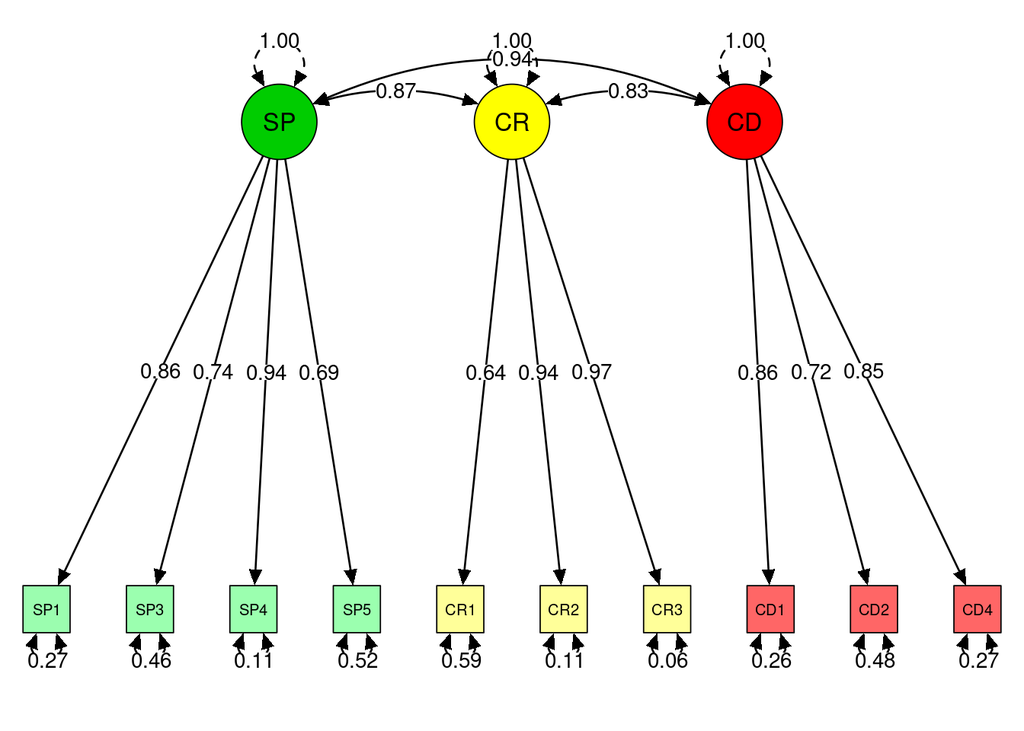

```
##                                     CO2.fit
## npar                            33.00000000
## fmin                             0.29609300
## chisq                           38.49209037
## df                              32.00000000
## pvalue                           0.19920384
## chisq.scaled                    26.73749148
## df.scaled                       32.00000000
## pvalue.scaled                    0.73010623
## chisq.scaling.factor             1.43962983
## baseline.chisq                 583.63119579
## baseline.df                     45.00000000
## baseline.pvalue                  0.00000000
## baseline.chisq.scaled          487.22631678
## baseline.df.scaled              45.00000000
## baseline.pvalue.scaled           0.00000000
## baseline.chisq.scaling.factor    1.19786468
## cfi                              0.98794706
## tli                              0.98305055
## cfi.scaled                       1.00000000
## tli.scaled                       1.01673442
## cfi.robust                       1.00000000
## tli.robust                       1.02011193
## logl                          -644.70163325
## unrestricted.logl             -625.45558806
## aic                           1355.40326650
## bic                           1427.15804640
## ntotal                          65.00000000
## bic2                          1323.28234653
## rmsea                            0.05586768
## rmsea.ci.lower                   0.00000000
## rmsea.ci.upper                   0.11243156
## rmsea.ci.level                   0.90000000
## rmsea.pvalue                     0.41297390
## rmsea.close.h0                   0.05000000
## rmsea.notclose.pvalue            0.27923571
## rmsea.notclose.h0                0.08000000
## rmsea.scaled                     0.00000000
## rmsea.ci.lower.scaled            0.00000000
## rmsea.ci.upper.scaled            0.05752564
## rmsea.pvalue.scaled              0.92574605
## rmsea.notclose.pvalue.scaled     0.00946886
## rmsea.robust                     0.00000000
## rmsea.ci.lower.robust            0.00000000
## rmsea.ci.upper.robust            0.08348741
## rmsea.pvalue.robust              0.84484116
## rmsea.notclose.pvalue.robust     0.05828715
## srmr                             0.03822860
```

# Bottom-Up Estimation with Model Implied Instrumental Variables

Let us re-estimate the unidimensionality of the Specialization sub-scale

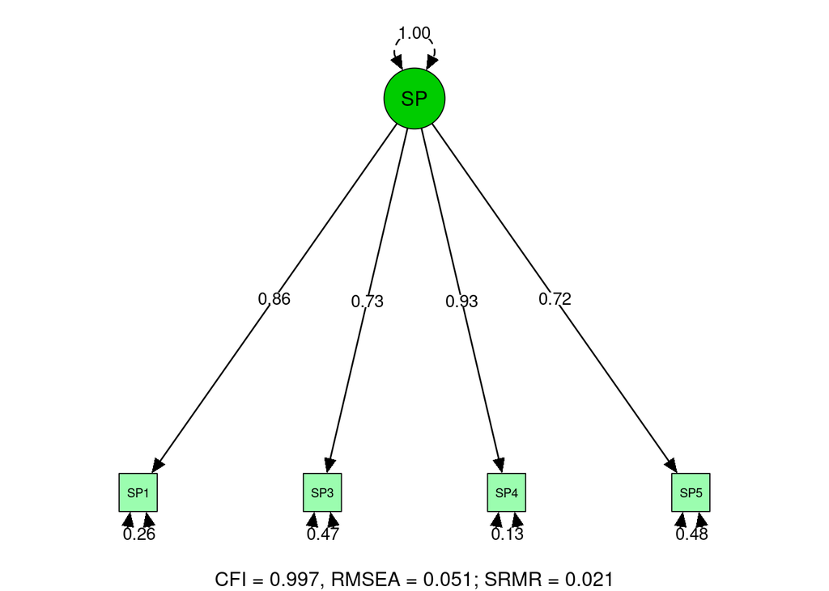

[figure not shown]